# Project 2: Dimension Reduction

Huong Ngo

02-25-2022

## Part 1

### Implementing PCA

```r
# Function: run_pca, performs PCA on a data matrix
# Input: X, must be a dataframe or matrix; scale, must be logical value
# Output: List of elements
        # prin_comps - matrix with the same dimensions as X that contains the principal components vectors
        # loadings - matrix of variable loadings, should be a square matrix where the number of rows and columns are equal to the number of columns of X
        # portion_var - vector of variances explained by each principal component
run_pca <- function(X, scale) {
  # Checks that X is a matrix
  if (!is.matrix(X)) {
    # Checks that X is a dataframe, if not a matrix
    if (!is.data.frame(X)) {
      stop("X must be a matrix or dataframe!")
    }
  }
  # Checks that scale is a logical value
  if (!is.logical(scale)) {
    stop("scale must be a logical value!")
  }

  # In the case that X is a dataframe, we will convert it to a matrix
  X <- as.matrix(X)
  # Checks if scale is true
  if(scale == TRUE) {
    # For each variable
    for (i in 1:ncol(X)) {
      # Calculate mean of the variable
      mean = mean(X[, i])
      # Calculate standard deviation of the variable
      sd = sd(X[, i])
      # For each observation
      for (j in 1:nrow(X)) {
        # Calculate the subtraction of the mean from the observation value and division of the standard deviation
        X[j, i] <- (X[j, i] - mean) / sd
      }
    }
    # Otherwise (scale is not true)
  } else {
    # For each variable
    for (i in 1:ncol(X)) {
      # Calculate mean of the variable
      mean = mean(X[, i])
      # For each observation
      for (j in 1:nrow(X)) {
        # Calculate the subtraction of the mean from the observation value
        X[j, i] <- (X[j, i] - mean)
      }
    }
  }

  # Using `cov` to generate the empirical covariance matrix of the data matrix X
  cov_mat <- cov(X)
  # Using eigen() to perform eigendecomposition of covariance matrix
  decomp_mat <- eigen(cov_mat)
  # Saving the vector of variances to a variable
  portion_var <- decomp_mat$values
  # Saving the matrix of principal component vectors to a variable
  loadings <- decomp_mat$vectors
  # Saving the matrix of loadings to a variable
  prin_comps <- X %*% loadings

  # Creating a list that contains the loadings matrix, principal components matrix and variances vector to be returned
  result <- list("loadings" = loadings,
                 "prin_comps" = prin_comps,
                 "portion_var" = portion_var)

  return(result)
}
```

```r
set.seed(302)
X <- matrix(nrow = 4, ncol = 3)
X[, 1] <- rnorm(4, mean = 0, sd = 1)
X[, 2] <- rnorm(4, mean = 0, sd = 10)
X[, 3] <- rnorm(4, mean = 0, sd = 15)
```

### Testing PCA

```r
# Running PCA(scaled) on matrix X and printing it
print(run_pca(X, scale = TRUE))
```

```
## $loadings
##            [,1]         [,2]      [,3]
## [1,]  0.7084795 -0.001857908 0.7057289
## [2,] -0.5547743 -0.619565369 0.5553055
## [3,] -0.4362135  0.784942866 0.4399801
##
## $prin_comps
##            [,1]       [,2]         [,3]
## [1,] -0.7560208  0.4093017  0.177129784
## [2,] -0.3393127 -1.4709209 -0.027876940
## [3,] -0.9751796  0.7839786 -0.142327150
## [4,]  2.0705130  0.2776406 -0.006925694
##
## $portion_var
## [1] 1.97490002 1.00761429 0.01748569
```

```r
# Running PCA on matrix X and printing it
print(run_pca(X, scale = FALSE))
```

```
## $loadings
##              [,1]         [,2]      [,3]
## [1,]  0.042487821  0.239115929 0.9700610
## [2,]  0.001277438 -0.970949987 0.2392791
## [3,] -0.999096168  0.008927255 0.0415590
##
## $prin_comps
##           [,1]        [,2]        [,3]
## [1,] -13.55252 -1.05491906  0.30259659
## [2,]  18.90252 -4.54935358 -0.05120845
## [3,] -18.19956  0.01014627 -0.26729080
## [4,]  12.84956  5.59412638  0.01590267
##
## $portion_var
## [1] 345.77042619  17.70127504   0.05529476
```

Referencing the results from the project document, the results are the same.

## Part 2

### Introduction

The datasets used for this project are from the Environmental Performance Index project by Yale University. The first dataset contains the environmental indicators that the project has measured for each country. The environmental indicators are abbreviated in the dataset and their full names can be referred in the technical appendix. The second dataset contains information about the region of the specific country, a binary variable indicating whether the country is a developer or less developed country, another binary variable indicating whether the country has emerging markets, the GDP of a specific country and the composite indicator of environmental performance (EPI) of the country.

### Loadings from First Two Principal Components

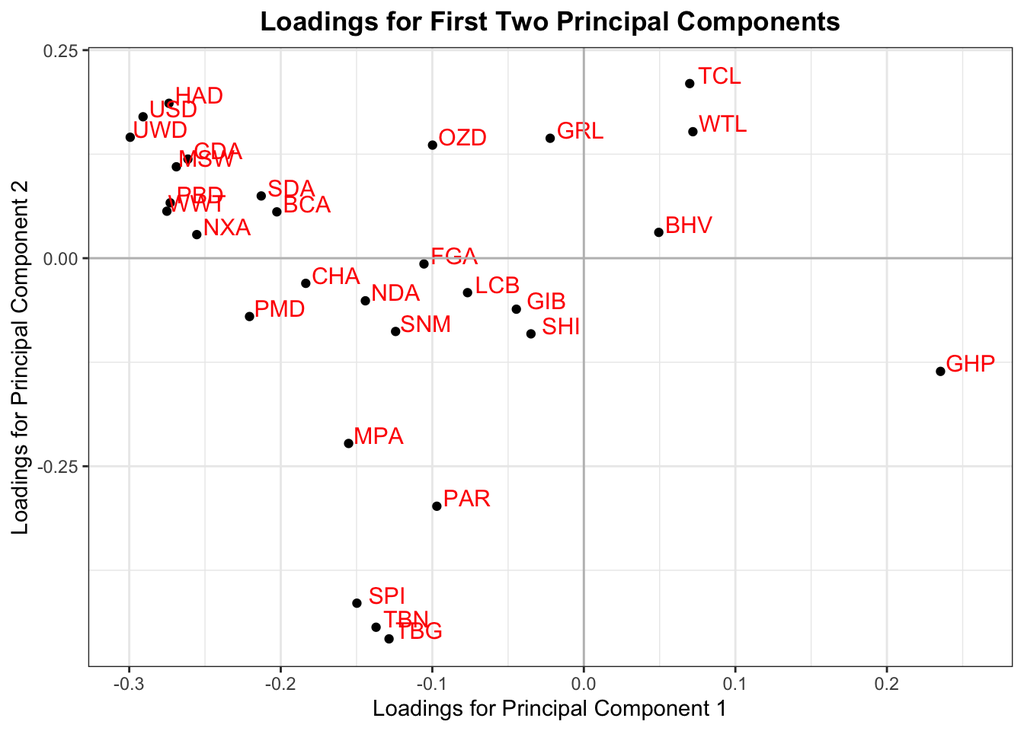

The plot above represents the loadings (coefficients) for the first two principal components. The x-axis has the loadings for principal component 1, and the y-axis has the loadings for principal component 2.

Firstly, we can note that we can’t discard the second principal component or the first one because both contribute a great amount of variation captured in the dataset. The only variable that has its variation almost fully captured by the first principal component is FGA - F.gas Growth Rate.

Another relationship can be interpreted from the loadings of the second component. Seeing that TCL - Tree Cover Loss and WTL - Wetland Loss are dominating coefficients, and on the other extreme, TBG - Terrestrial Biome Protection (Global) and SPI - Species Protection Index have negative coefficients, we can interpret the second principal components to reflect the harmful environmental actions to cause loss of species and damage of biomes.

### First Two Principal Components

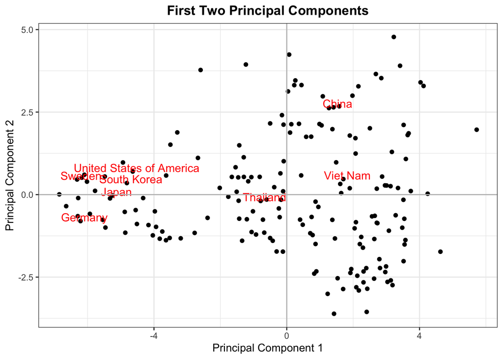

The plot above represents the first two principal components. The x-axis is the principal component 1, and the y-axis is the principal component 2.

From the labeled representative countries on the scatterplot, we can see that there is a group of countries that are quite similar in terms of environmental factors. United States of America, Sweden, South Korea and Japan can be seen quite close to each other and forming a cluster. We can interpret this as how these countries share many similarities in values of the environmental indicators, which could further mean that they are quite similar in environmental goals, policies and progress. Thailand, China and Vietnam on the other hand are quite far from each other and from that group, with China being the furthest from the cluster. We can interpret this as how these countries share very few similarities in terms of how they deal with their local environment and that they also don’t share similar environmental principles with the countries in the cluster, with China sharing the least similarities. The climate of those countries could explain why they don’t share much similarties with the ones in the cluster.

### Choosing the Ideal Number of Principal Components

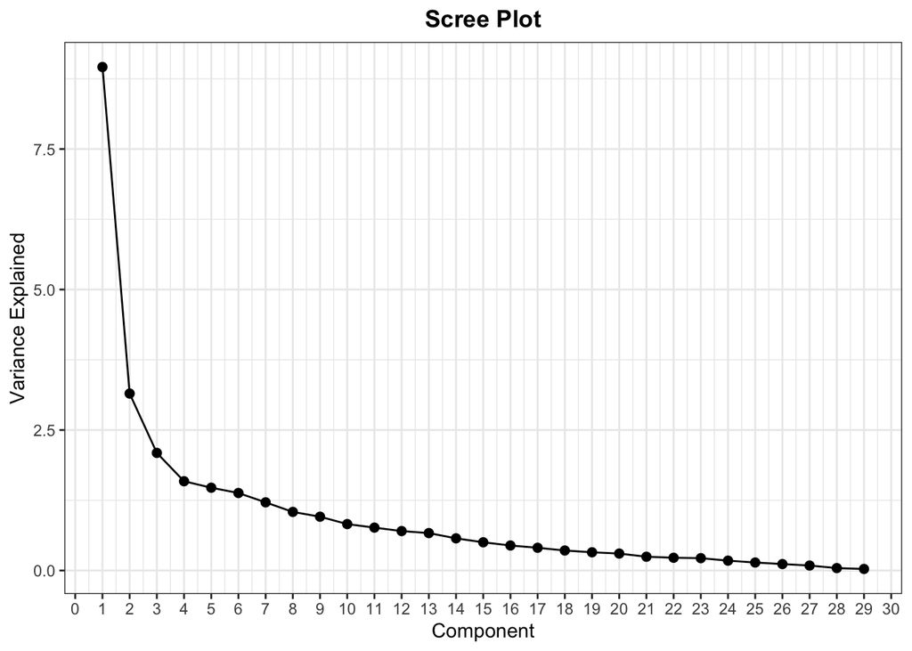

Three principal components is the ideal number to use. With a scree plot, we want to look for the “elbow” - a specific component number where after that component, the difference in variance starts looking consistent/the change in variance captured by each principal component is not drastic relative to the first few changes. Above, we can see that the change starts becoming not drastic after the third principal component. Therefore, we just want to pick the first, second and third. We also don’t want to pick more given that it can be extremely difficult to create graphs in 4 dimensions/more and interpret them.

### EDA with PCA

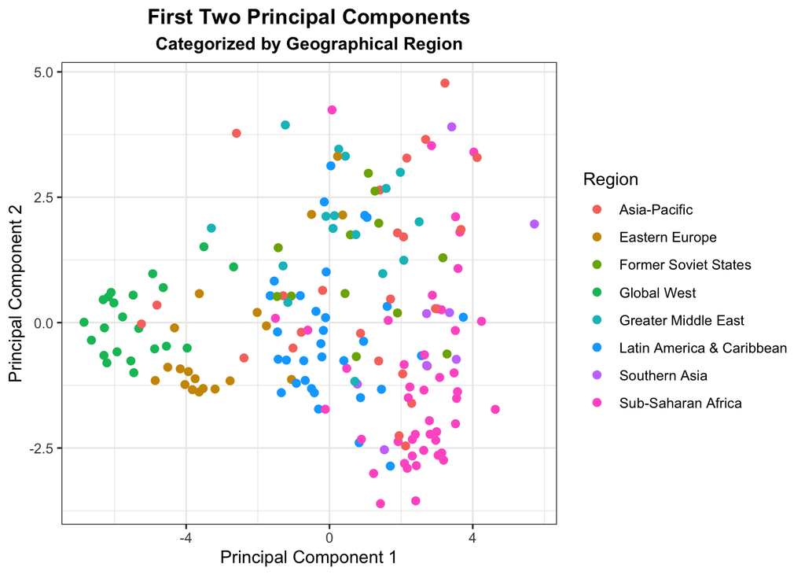

The plot above represents the first two principal components, but the country variables are categorized by their associated geographical region. The x-axis is the first principal component, and the y-axis is the second principal component.

From the scatterplot above, we can see that countries in the Global West, Latin America & Caribbean and Sub-Saharan Africa share many similarities about environmental indicator values. Essentially, the countries in their respective share many environmental aspects such as policies, goals and initiatives among each other. However, the other regions such as Asia-Pacific, Southern Asia and Greater Middle East have countries that don’t share much similarities with each other compared to the former. This is quite interesting to note, and an aspect that can play a role into this phenomenon would be varying climates in the latter regions and how spread out the countries are within those regions.

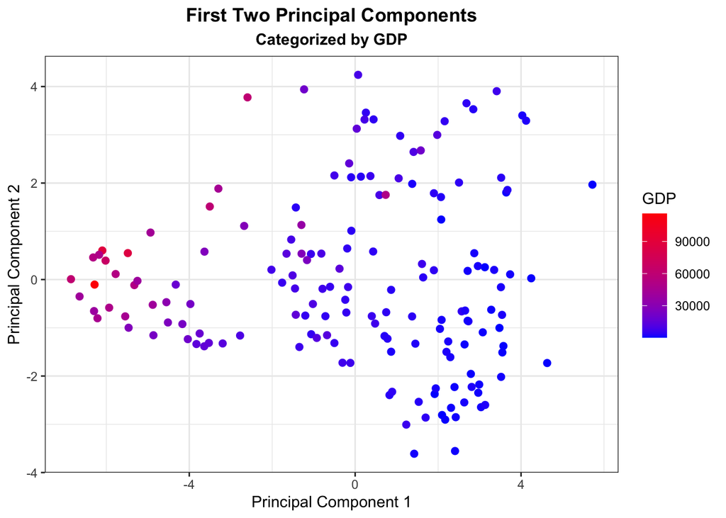

The plot above represents the first two principal components, but the country variables are categorized by their associated GDP. The x-axis is the first principal component, and the y-axis is the second principal component.

Looking at this figure, we can see that there are certain groups/clusters of countries formed by the differences in GDP. A notable thing we can take away from the figure is that countries with low GDP’s are clustered on the right side of the plot, countries with the middle GDP’s are clustered somewhat in the center and countries with high GDP’s are clustered on the left side of the plot. Combining this with our interpretations of the first scatterplot, we can interpret GDP to be a good indicator of the environmental progress a country is making. This reflects how countries with a low GDP have less infrastructure and resources to improve their environment while other countries with a high GDP can spend a lot of money in improving and sustaining their local environment.

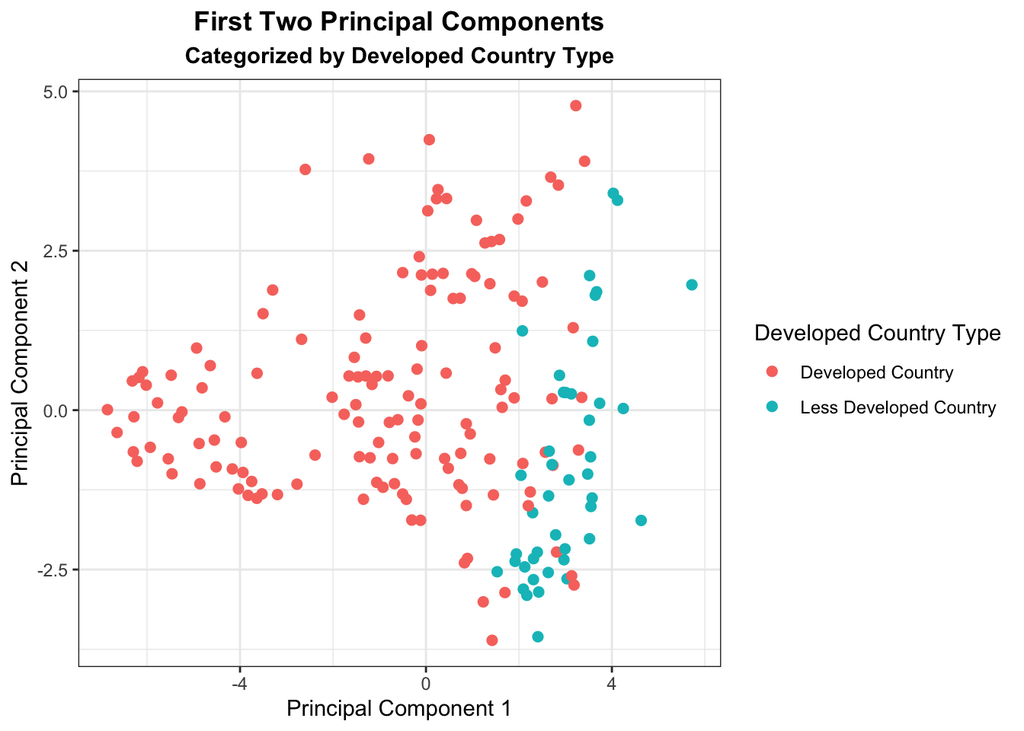

The plot above represents the first two principal components, but the country variables are categorized by whether they are a developed country or less developed country. The x-axis is the first principal component, and the y-axis is the second principal component.

### EPI vs. First Principal Component

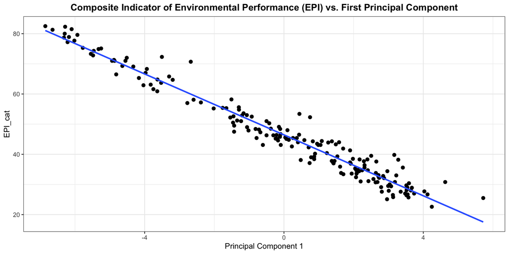

```
##                pc1    epi_cat
## pc1      1.0000000 -0.9783297
## epi_cat -0.9783297  1.0000000
```

The plot above is a scatterplot to showcase the relationship between the EPI variable and first principal component. The x-axis is the first principal component, and the y-axis is the EPI variable.

To compare the first principal component to the variable EPI in the second dataset, we can look at the scatterplot above and reference the correlation coefficient: `-0.978`.

Looking at the scatterplot, it is clear that their a linear and inverse relationship between the 2 variables. This is also confirmed by the negative correlation coefficient, which also means that there is a negative correlation between these 2 variables. Given that they share the same best fit line, we can see that they are similar to each other. Moreover, given that the first principal component usually captures the most variance in the dataset and EPI is a variable used to summarize all the indicators, they should be similar. We can take note that the negative slope could originate from the principal components being a product of the scaled dataset, while the EPI values could be directly from the dataset. That’s also probably why the EPI values are so much larger in magnitude that the coefficients of the first principal component.

### Code Appendix

```r
# Data Setup
# Retrieving dataset that excludes country name column
env_ind_pca <- env_ind[2:30]
# Run PCA on modified Dataset 1 (env_ind) and scaling it, using `run_pca`
reduced_env_ind <- run_pca(env_ind_pca, scale = TRUE)

# Retrieving the matrix of variable loadings from the list of returned elements from `run_pca` and making it a dataframe
env_ind_loadings <- as.data.frame(reduced_env_ind$loadings)
# Mutating a column that contains the environmental indicators to the loadings dataframe and renaming the column
env_ind_loadings <- env_ind_loadings %>%
  add_column(colnames(env_ind_pca)) %>%
  rename("indicator" = "colnames(env_ind_pca)")

# Retrieving the matrix of principal component vectors from the list of returned elements from `run_pca` and making it a dataframe
env_ind_prin_comps <- as.data.frame(reduced_env_ind$prin_comps)
# Mutating a column that contains the country names to the principal components dataframe and renaming the column
env_ind_prin_comps <- env_ind_prin_comps %>%
  add_column(env_ind$country) %>%
  rename("country" = "env_ind$country")

# Retrieving the vector of variances explained by each principal component from the list of returned elements from `run_pca` and making it a dataframe
var_prop <- as.data.frame(reduced_env_ind$portion_var)
# Mutating a column that contains the corresponding principal component number to the variances dataframe and renaming the column. Also renaming the column that contains teh variances.
var_prop <- var_prop %>%
  add_column(c(1:29)) %>%
  rename("variance" = "reduced_env_ind$portion_var",
         "component" = "c(1:29)")
```

```r
# Figure 1
# Loading for First Two Principal Components
ggplot(data = env_ind_loadings,
       aes(x = V1,
           y = V2,
           label = indicator)) +
  geom_point() +
  geom_text(size = 4,
            nudge_x = 0.02,
            nudge_y = 0.01,
            color = "red") +
  geom_vline(xintercept = 0, color = "grey") +
  geom_hline(yintercept = 0, color = "grey") +
  labs(title = "Loadings for First Two Principal Components",
       x = "Loadings for Principal Component 1",
       y = "Loadings for Principal Component 2") +
  theme_bw() +
  theme(plot.title = element_text(hjust = 0.5, face = "bold"))
```

```r
# Figure 2
# First Two Principal Components
text_df <- env_ind_prin_comps %>%
  filter(country %in% c("United States of America",
                        "South Korea",
                        "Viet Nam",
                        "China",
                        "Germany",
                        "Japan",
                        "Thailand",
                        "Sweden"))
ggplot(data = env_ind_prin_comps,
       aes(x = V1,
           y = V2,
           label = country)) +
  geom_point() +
  geom_text(data = text_df,
            size = 4,
            nudge_x = .12,
            nudge_y = .12,
            color = "red") +
  geom_vline(xintercept = 0, color = "grey") +
  geom_hline(yintercept = 0, color = "grey") +
  labs(title = "First Two Principal Components",
       x = "Principal Component 1",
       y = "Principal Component 2") +
  theme_bw() +
  theme(plot.title = element_text(hjust = 0.5, face = "bold"))
```

```r
# Figure 3
# Scree Plot
ggplot(data = var_prop, aes(x = component,
                            y = variance)) +
  geom_point(size = 2) +
  geom_line() +
  labs(title = "Scree Plot",
       x = "Component",
       y = "Variance Explained") +
  theme_bw() +
  theme(plot.title = element_text(hjust = 0.5, face = "bold")) +
  scale_x_continuous(n.breaks = 29)
```

```r
# Figure 4
# First Two Principal Components (Categorized by Geographical Region)
plot_df <- data.frame(pc1 = env_ind_prin_comps$V1,
                      pc2 = env_ind_prin_comps$V2,
                      region = country_data$region)
ggplot(data = plot_df, aes(x = pc1,
                           y = pc2,
                           color = as.factor(region))) +
  geom_point(size = 2) +
  labs(title = "First Two Principal Components",
       subtitle = "Categorized by Geographical Region",
       x = "Principal Component 1",
       y = "Principal Component 2",
       color = "Region") +
  theme_bw() +
  theme(plot.title = element_text(hjust = 0.5, face = "bold"),
        plot.subtitle = element_text(hjust = 0.5, face = "bold"))
```

```r
# Figure 5
# First Two Principal Components (Categorized by GDP)
plot_df_2 <- data.frame(pc1 = env_ind_prin_comps$V1,
                        pc2 = env_ind_prin_comps$V2,
                        gdp = country_data$gdp)
ggplot(data = plot_df_2 %>%
         filter(!is.na(gdp)), aes(x = pc1,
                             y = pc2,
                             color = gdp)) +
  geom_point(size = 2) +
  labs(title = "First Two Principal Components",
       subtitle = "Categorized by GDP",
       x = "Principal Component 1",
       y = "Principal Component 2",
       color = "GDP") +
  theme_bw() +
  theme(plot.title = element_text(hjust = 0.5, face = "bold"),
        plot.subtitle = element_text(hjust = 0.5, face = "bold")) +
  scale_color_continuous(low = "blue", high = "red")
```

```r
# Figure 6
# First Two Principal Components (Categorized by Developed Country Type)
plot_df_3 <- data.frame(pc1 = env_ind_prin_comps$V1,
                      pc2 = env_ind_prin_comps$V2,
                      ldc = country_data$ldc)
plot_df_3 <- plot_df_3 %>% mutate(ldc_desc = case_when(ldc == 0 ~ "Developed Country",
                                                       ldc == 1 ~ "Less Developed Country"))

ggplot(data = plot_df_3, aes(x = pc1,
                           y = pc2,
                           color = as.factor(ldc_desc))) +
  geom_point(size = 2) +
  labs(title = "First Two Principal Components",
       subtitle = "Categorized by Developed Country Type",
       x = "Principal Component 1",
       y = "Principal Component 2",
       color = "Developed Country Type") +
  theme_bw() +
  theme(plot.title = element_text(hjust = 0.5, face = "bold"),
        plot.subtitle = element_text(hjust = 0.5, face = "bold"))
```

```r
# Figure 7
# Composite Indicator of Environmental Performance (EPI) vs. First Principal Component
plot_df_4 <- data.frame(pc1 = env_ind_prin_comps$V1,
                        epi_cat = country_data$EPI_cat)
ggplot(data = plot_df_4, aes(x = pc1, y = epi_cat)) +
  geom_point(size = 2) +
  geom_smooth(method = lm, se = FALSE) +
  labs(title = "Composite Indicator of Environmental Performance (EPI) vs. First Principal Component",
       x = "Principal Component 1",
       y = "EPI_cat") +
  theme_bw() +
  theme(plot.title = element_text(hjust = 0.5, face = "bold"),
        plot.subtitle = element_text(hjust = 0.5, face = "bold"))

# Calculate correlation matrix using `cor`
cor(plot_df_4)
```